# Advanced Energy System Design (AESD): Technical Manual for the Records API (NREL TP-6A20-68924)

Nicholas Brunhart-Lupo

Brian Bush

Kenny Gruchalla

Michael Rossol *National Renewable Energy Laboratory

9 January 2018

# 1 Abstract

The Records API (application program interface) for Advanced Energy System Design (AESD) enables software that serves multidimensional record-oriented data to interoperate with software than uses such data. In the context of the Records API, multidimensional data records are simply tuples of real numbers, integers, and character strings, where each data value is tagged by a variable name, according to a pre-defined schema, and each record is assigned a unique integer identifier. Conceptually, these records are isomorphic to rows in a relational database, JSON objects, or key-value maps. Records servers might supply static datasets, sensor measurements that periodically update as new telemetry become available, or the results of simulations as the simulations generate new output. Records client software might display or analyze the data, but in the case of simulations the client request the creation of new ensembles for specified input parameters. It is also possible to chain records clients and servers together so that a client consuming data from a server might transform that data and serve it to additional clients.

# 2 Overview

Client-server communication in the Records API simply consists of clients sending `Request` messages to the server and servers asynchronously sending `Response` messages to the client. The request and response messages hold the specifics of the request or response and the responses are correlated with the requests; however, it is important to note that multiple responses may occur for a single request, as when record data are chunked into multiple response, or that an error response may be sent at any time. The nested messages within `Request` and `Response` may in turn contain nested fields and messages providing further details. The table below shows the correspondence between requests and responses, while the figure following that shows the containment relationships between message types.

Correlation between requests and responses.

| Request Field | Response Field |
| --- | --- |
| `models_metadata` | `models` or `error` |
| `records_data` | `data` or `error` |
| `bookmark_meta` | `bookmarks` or `error` |
| `save_bookmark` | `bookmarks` or `error` |
| `cancel` | no response or `error` |
| `work` | `data` or `error` |

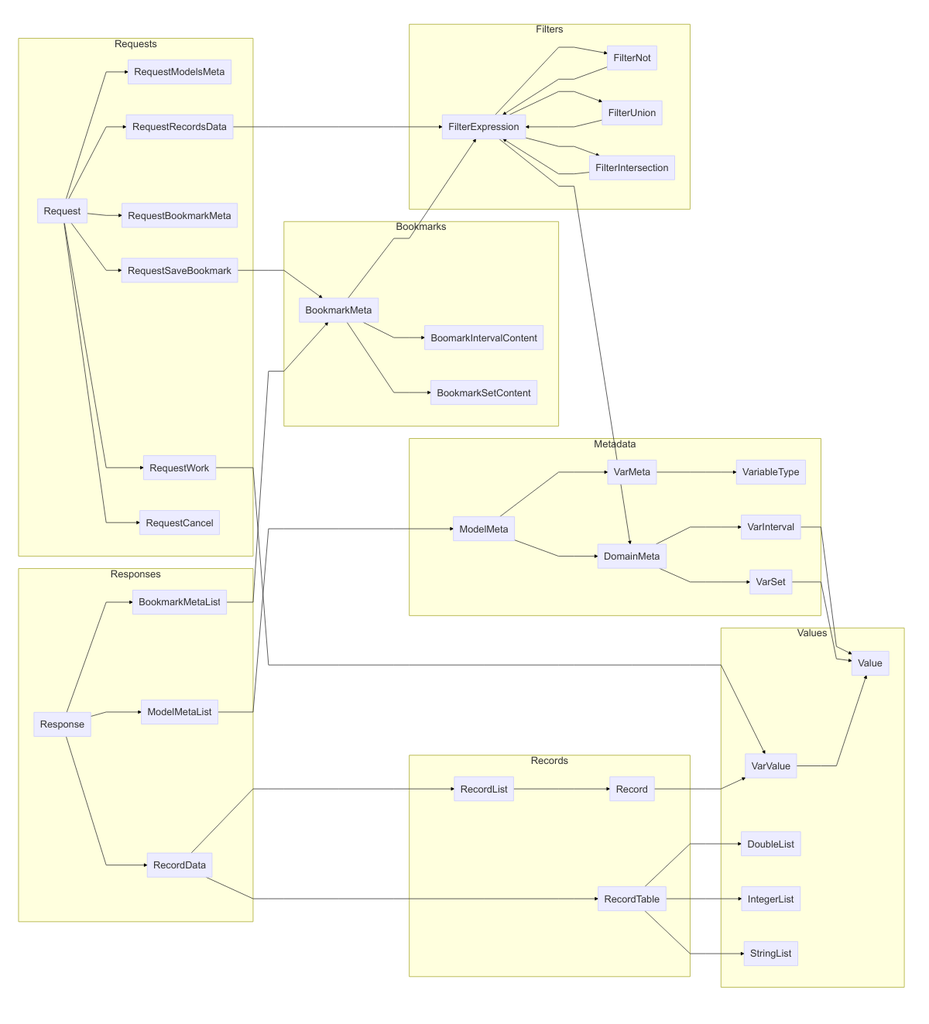

Containment relationships between protocol buffer messages in the Records API.

Metadata messages describe “models”, which are just sources of data, and the variables they contain. Data record messages hold the data itself. Data records are simply tuples of real numbers, integers, and character strings, where each data value is tagged by a variable name, according to a pre-defined schema, and each record is assigned a unique integer identifier. Conceptually, these records are isomorphic to rows in a relational database, JSON objects, or key-value maps. For efficiency and compactness, `RecordData` may be provided in list format or tabular format, with the latter format obtained only when the contents of the table all have the same data type. The data records may be provided *in toto* or filtered using filter messages so that only certain fields or records are returned. The API contains a small embedded language for filtering via set and value operations. Sets of records may be bookmarked for sharing or later retrieval by (i) enumerating their unique record identifiers, (ii) defining a range of unique record identifiers, or (iii) specifying a filtering criterion.

Servers that perform computations or simulations can receive input parameters via a `RequestWork` message that contains those input parameters. After the server has completed its computations, it sends the results as `RecordData` messages.

In general the response to a request for data records comes in *chunks* numbered in sequence, where each chunk has an identifier, `chunk_id`, and the response specifies the identifier of the next chunk, `next_chunk_id`. Thus, the chunks form a linked list. The sending of additional chunks can be cancelled using a `RequestCancel` message. If the `subscribe` flag is set when making a request, the server will respond indefinitely with additional data as it becomes available, until the subscription is cancelled.

# 3 Use Cases

In this section we outline some standard use cases for the Records API. UML Sequence Diagrams (Fowler 2017) illustrate the flow of messages and the messages themselves are printed in the text format output by the Google `protoc` tool (Google Developers 2017a).

## 3.1 Static Data

The retrieval of static data records forms the simplest use case for the Records API. A user chooses a particular data source (a “model” in the parlance of the Records API) and then the data are retrieved and displayed. The visualization client software communicates with a Records server, which in turn accesses the static data. The figure below illustrates the process.

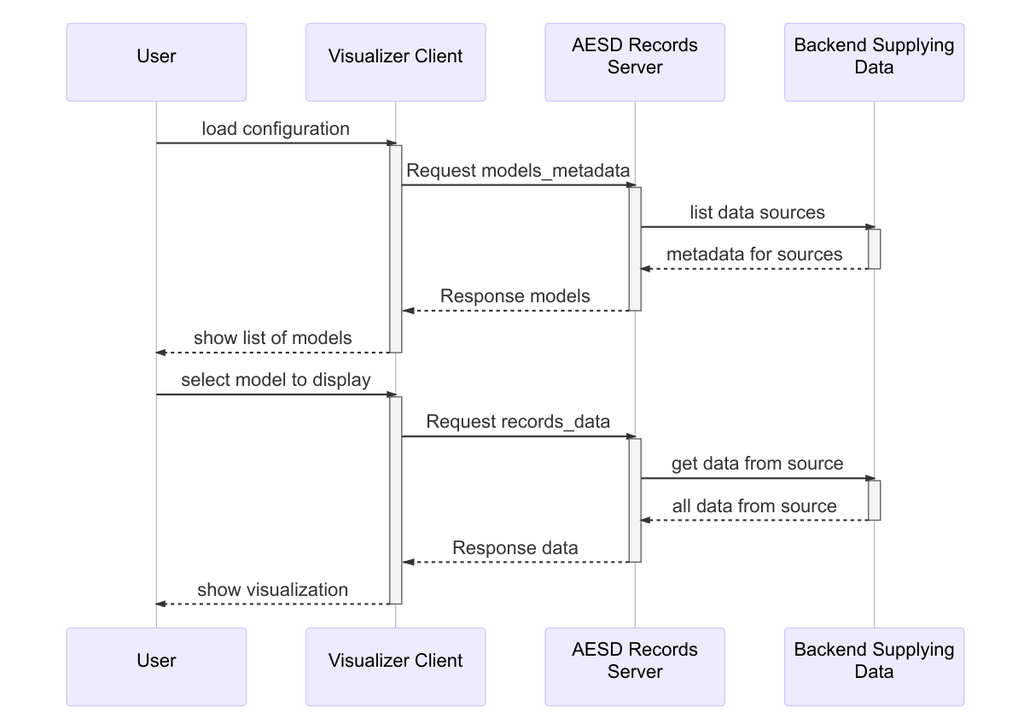

Visualizing data from a static source using the Records API.

A `Request` without `model_id` specified requests the server to list all models:

```
version: 4
id: 1
models_metadata {
}
```

The `Response` from the server provides metadata for all of the models:

[output not shown]

[output cut: 10 more lines]

[output not shown]

Note that the response above is tagged with the same `id` as the request: this allows the client to correlate responses with the particular requests it makes. Next the user might request three records from the first model:

```
version: 4
id: 2
records_data {
  model_id: "example-model-1"
  max_records: 3
}
```

The record data might be returned as two chunks, where the first chunk is

```
version: 4
id: 2
chunk_id: 1
next_chunk_id: 2
data {
  list {
    records {
      record_id: 10
      variables {
        var_id: 0
        value: 10.5
      }
      variables {
        var_id: 1
        value: -5
      }
      variables {
        var_id: 2
        value: "first"
      }
    }
    records {
      record_id: 20
      variables {
        var_id: 0
        value: 99.2
      }
      variables {
        var_id: 1
        value: 108
      }
      variables {
        var_id: 2
        value: "second"
      }
    }
  }
}
```

and the last chunk is:

```
version: 4
id: 2
chunk_id: 2
next_chunk_id: 0
data {
  list {
    records {
      record_id: 30
      variables {
        var_id: 0
        value: -15.7
      }
      variables {
        var_id: 1
        value: 30
      }
      variables {
        var_id: 2
        value: "third"
      }
    }
  }
}
```

## 3.2 Dynamic Data

As shown in the following figure retrieving data from a dynamic source proceeds quite similarly to retrieving data from a static source. The only essential difference is that the server repeatedly sends additional responses containing new data, until a request to cancel is sent.

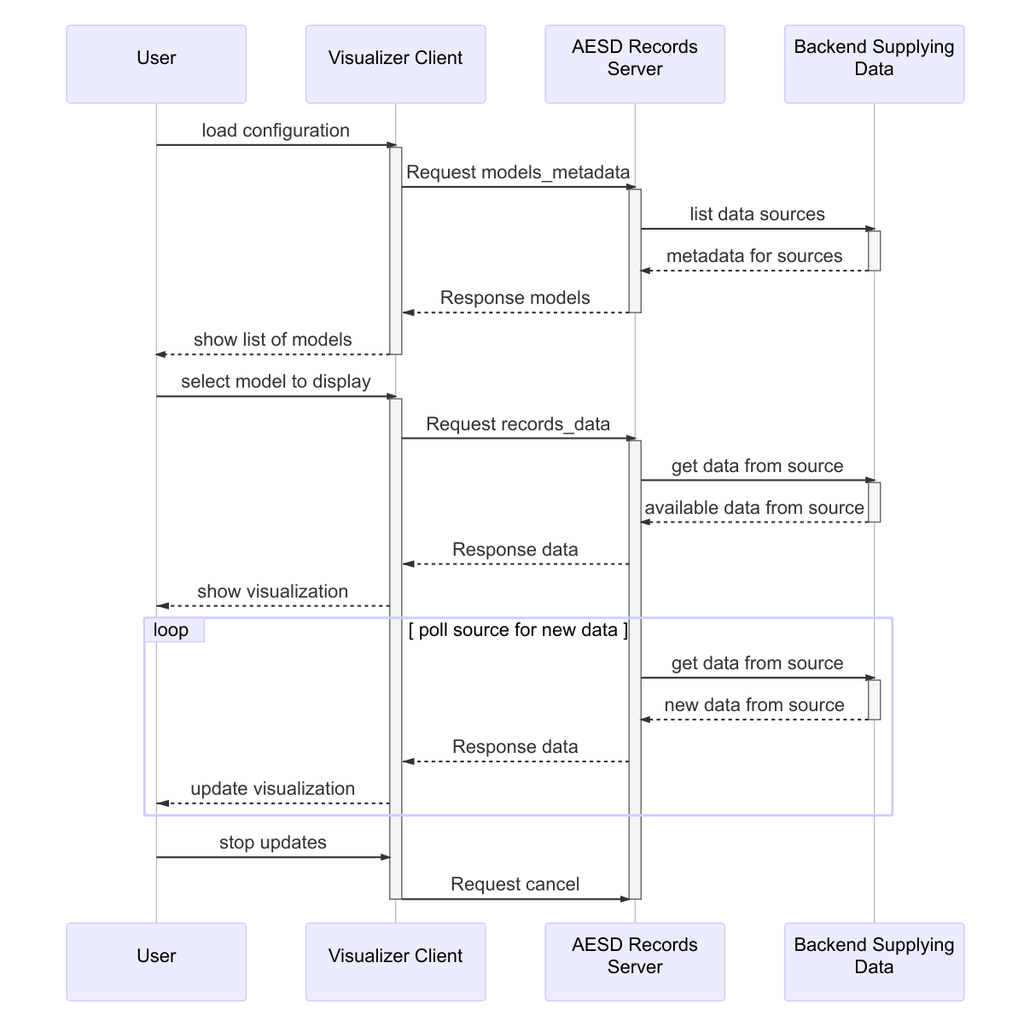

Visualizing data from a dynamic source using the Records API.

When requesting dynamic data, it is advisable to set the `subscribe` flag in the request for data:

```
version: 4
id: 2
subscribe: true
records_data {
  model_id: "example-model-2"
}
```

The `RequestCancel` message is the `cancel` field `Request` and must include the `id` of the request to be cancelled:

```
version: 4
cancel {
  id: 2
}
```

## 3.3 Simulations

The model `Example Simulation #3` in the Static Data use case is a simulation model, as evidenced by the presence of the `inputs` field in its metadata. The following figure shows a typical interaction with a simulation-based model via the Records API.

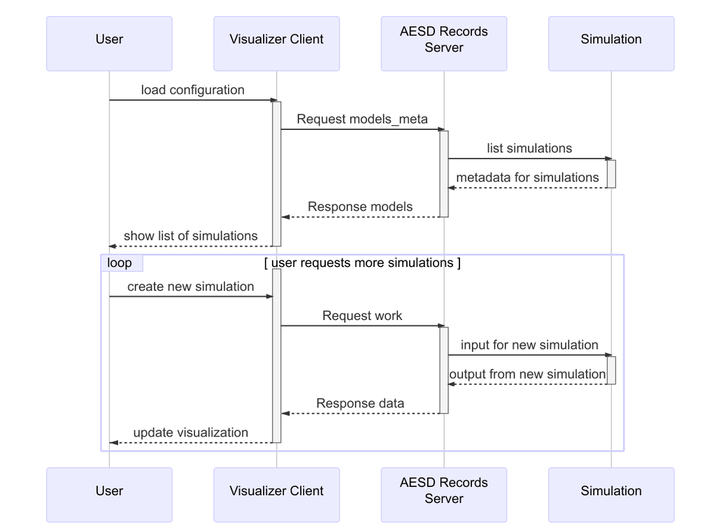

Steering and visualizing simulation results using the Records API.

The `RequestWork` message, which is contained in the `work` field of a `Request`, specifies the input for a simulation to be run:

```
version: 4
id: 3
work {
  model_id: "example-simulation-3"
  inputs {
    var_id: 0
    value: 50
  }
}
```

The response to this message will be data for the result of the simulation.

## 3.4 Bookmarks

Once data from a model is loaded, it may be bookmarked. One simply supplies a description of the data to be bookmarked. Bookmarks can be listed and loaded, as shown in the following figure.

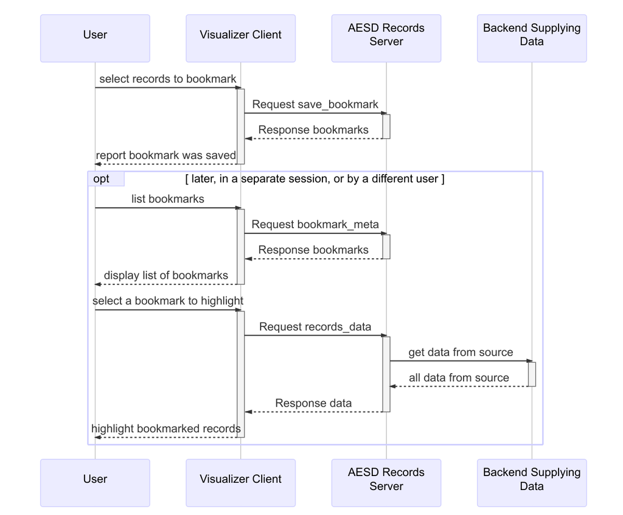

Creating and retrieving a bookmark and its associated data.

To create a bookmark for a specific list of records, simply supply their record identifiers as part of a `BookmarkMeta` message in the `save_bookmark` field of `Request`:

```
version: 4
id: 4
save_bookmark {
  model_id: "example-model-1"
  new_bookmark {
    bookmark_name: "Sample Bookmark"
    set {
      record_ids: 10
      record_ids: 30
    }
  }
}
```

The response will be the same bookmark, but with the `bookmark_id` field added:

```
version: 4
id: 4
bookmarks {
  bookmark_metas {
    bookmark_id: "bookmark-1"
    bookmark_name: "Sample Bookmark"
    set {
      record_ids: 10
      record_ids: 30
    }
  }
}
```

The user or another user can retrieve the records corresponding to the bookmark:

```
version: 4
id: 5
records_data {
  model_id: "example-model-1"
  bookmark_id: "bookmark-1"
}
```

This will return precisely the bookmarked records:

```
version: 4
id: 5
data {
  list {
    records {
      record_id: 10
      variables {
        var_id: 0
        value: 10.5
      }
      variables {
        var_id: 1
        value: -5
      }
      variables {
        var_id: 2
        value: "first"
      }
    }
    records {
      record_id: 30
      variables {
        var_id: 0
        value: -15.7
      }
      variables {
        var_id: 1
        value: 30
      }
      variables {
        var_id: 2
        value: "third"
      }
    }
  }
}
```

## 3.5 Filtering

Filtering records can be used to select particular records for retrieval, via the `RequestRecordsData` message, or in defining bookmarks, via the `BookmarkMeta` message. Filtering of records is accomplished through expressions, `FilterExpression`, combining values for variables, `DomainMeta`, and the set operators not, union, and intersection, encoded in the messages `FilterNot`, `FilterUnion`, and `FitlerIntersection`, respectively. For example, the expression *x* ≤ 20 would be expressed as the following `FilterExpression`

```
filter_domain {
  interval {
    var_id: 0
    last_value: 20
  }
}
```

provided that *x* has `var_id = 0`. The expression (10 ≤ *x* ≤ 20)∪(*y* ∉ {4, 7}) would be expressed as

```
filter_union {
  filter_expressions {
    filter_domain {
      var_id: 0
      first_value: 10
      last_value: 20
    }
    filter_not {
      filter_expression {
        filter_domain {
          var_id: 1
          set {
            elements: 4
            elements: 7
          }

      }
    }
  }
}
```

provided that *x* has `var_id = 0` and *y* has `var_id = 1`.

# 4 Records API, Version 4

The AESD Records API consists of Google Protobuf 3 (Google Developers 2017b) messages used to request and provid data and metadata for record-oriented information. This section contains the complete specification for version 4 of the Records API. Clients send `Request` messages and servers send `Response` messages, typically transported via WebSockets (Internet Engineering Task Force 2017).

## 4.1 Message Groups

The message types in the Records API are organized into thematic groups below.

### 4.1.1 Requests and Responses

`Request` messages are sent from client to server and `Response` messages are sent from server to client. Request messages contain a specific type of request and response messages contain a corresponding specific type of response.

- Request
- RequestModelsMeta
- RequestRecordsData
- RequestWork
- RequestBoomarkMeta
- RequestSaveBookmark
- RequestCancel
- Response

### 4.1.2 Metadata

Metadata messages describe data sources (“models”) and variables.

- ModelMeta
- ModelMetaList
- DomainMeta
- VarMeta
- VariableType
- VarSet
- VarInterval

### 4.1.3 Data Records

Data are represented as either lists of records or tables of them.

- Record
- VarValue
- Value
- RecordData
- RecordList
- RecordTable

### 4.1.4 Filtering

Records can be filtered by logical operations on conditions for values of variables in the records.

- FilterExpression
- FilterNot
- FilterIntersection
- FilterUnion
- DomainMeta

### 4.1.5 Bookmarks

Bookmarks record particular sets or records or conditions for record data.

- BookmarkMeta
- BookmarkMetaList
- BookmarkIntervalContent
- BookmarkSetContent

### 4.1.6 Miscellaneous

The following messages wrap data types for the content of records.

- DoubleList
- IntegerList
- StringList
- OptionalInt32
- OptionalUInt32
- OptionalString

## 4.2 General Conventions

All fields are technically optional in ProtoBuf 3, but some fields may be required in each message type in order for the message to be semantically valid. In the following specifications for the messages, fields are annotated as *semantically required* or *semantically optional*. Also, the specification notes when field in the [protobuf `oneof` construct](https://developers.google.com/protocol-buffers/docs/proto3#oneof) are required or mutually exclusive.

Furthermore, one cannot determine whether an optional value has been set or not if it is just a value, as opposed to a message. That is not true for fields that are messages, where the absence of the field truly indicates that the value is absent, not just a default or unset value. The message `OptionalString`, for example, is used in this API to indicate whether a character string value is truly present. Thus `RequestModelsMeta` has a `model_id` field that indicates whether the request is for all models, when the field has not been set, or for a specific one, when the field has been set.

Throughout this specification, the following types are used for identifiers: * `var_id` is int32 * `model_id` is string * `record_id` is int64

This specification conforms to [Protocol Buffers version 3](https://developers.google.com/protocol-buffers/docs/proto3).

## 4.3 Messages

### 4.3.1 BookmarkIntervalContent

A range of record identifiers can specify the content of a bookmark. Bookmark interval content provides a convenient means to bookmark a contiguous selection of records in a model.

Both fields in this message are optional:

| Field | Type | Label | Description |
| --- | --- | --- | --- |
| first_record | int64 | optional | [semantically optional] The identifier for the first record in the interval. |
| last_record | int64 | optional | [semantically optional] The identifier for the last record in the interval. |

### 4.3.2 BookmarkMeta

A bookmark is metadata defining a subset of records in a model.

There are three alternatives to specifying a bookmark:

1. Interval content specifies a range of records in the bookmark.
2. Set content specifies a list of records in the bookmark.
3. A filter expression defines a set of logical conditions for determining whether a record is in the bookmark.

*Exactly one of `interval`, `set`, or `filter` must be specified in this message.*

| Field | Type | Label | Description |
| --- | --- | --- | --- |
| bookmark_id | string | optional | [semantically optional] When creating a new bookmark, this field must be empty: the server will create a unique identifier for the bookmark. This identifier uniquely identifies the bookmark *on the pa… |
| bookmark_name | string | optional | [semantically required] A name for the bookmark, which is useful for displaying the bookmark to users. This need not be unique, although it is recommended to be so. |
| interval | BookmarkIntervalContent | optional | The range of records in the bookmark. |
| set | BookmarkSetContent | optional | The list of records in the bookmark. |
| filter | FilterExpression | optional | Logical conditions for defining which records are in the bookmark. |

### 4.3.3 BookmarkMetaList

Bookmarks may be grouped into lists (sets).

| Field | Type | Label | Description |
| --- | --- | --- | --- |
| bookmark_metas | BookmarkMeta | repeated | [semantically optional] The bookmarks in the list. |

### 4.3.4 BookmarkSetContent

A list (set) of record identifiers can specify the contents of a bookmark. Bookmark-set content provides a convenient means to bookmark a specific selection of non-continuous records in a model.

| Field | Type | Label | Description |
| --- | --- | --- | --- |
| record_ids | int64 | repeated | [semantically optional] The list of record identifiers in the set. |

### 4.3.5 DomainMeta

The domain (set of valid values) for a variable.

There are two alternatives to specifying a domain:

1. An interval specifies a range of values in the domain.
2. A set specifies a list of values in the domain.

*Exactly one of `interval` or `set` must be specified in the message.*

| Field | Type | Label | Description |
| --- | --- | --- | --- |
| var_id | int32 | optional | [semantically required] |
| interval | VarInterval | optional | The interval of values in the domain. |
| set | VarSet | optional | The list of values in the domain. |

### 4.3.6 DoubleList

A list of real numbers.

| Field | Type | Label | Description |
| --- | --- | --- | --- |
| values | double | repeated | [semantically required] The real numbers. |

### 4.3.7 FilterExpression

A filtering expression is a composition of logical conditions on a record. It can be used to filter records. There are four alternatives to specifying a filter expression:

1. The logical negation of another filtering expression.
2. The set union of multiple filtering expressions.
3. The set intersection of multiple filtering expressions.
4. Particular values of variables in a record.

*Exactly one of `filter_not`, `filter_union`, `filter_intersection`, or `filter_domain` must be specified in this message.*

| Field | Type | Label | Description |
| --- | --- | --- | --- |
| filter_not | FilterNot | optional | Logical negation of an expression. |
| filter_union | FilterUnion | optional | Set union of expressions. |
| filter_intersection | FilterIntersection | optional | Set intersection of expressions. |
| filter_domain | DomainMeta | optional | Particular values of variables. |

### 4.3.8 FilterIntersection

Set intersection of filtering expressions. A record satisfies this expression if it satisfies all `filter_expressions`.

| Field | Type | Label | Description |
| --- | --- | --- | --- |
| filter_expressions | FilterExpression | repeated | [semantically required] The expressions to be intersected. |

### 4.3.9 FilterNot

Logically negate a filtering expression. A record satisfies this expression if it does not satisfy `filter_expression`.

| Field | Type | Label | Description |
| --- | --- | --- | --- |
| filter_expression | FilterExpression | optional | [semantically required] The expression to be negated. |

### 4.3.10 FilterUnion

Set union of filtering expressions. A record satisfies this expression if it satisfies any of `filter_expressions`.

| Field | Type | Label | Description |
| --- | --- | --- | --- |
| filter_expressions | FilterExpression | repeated | [semantically required] The expressions to be “unioned”. |

### 4.3.11 IntegerList

A list of integers.

| Field | Type | Label | Description |
| --- | --- | --- | --- |
| values | sint64 | repeated | [semantically required] The integers. |

### 4.3.12 ModelMeta

Metadata for a model.

| Field | Type | Label | Description |
| --- | --- | --- | --- |
| model_id | string | optional | [semantically required] The unique identifier for the model *on the particular server*. |
| model_name | string | optional | [semantically required] A name for the model, useful for display the model to users. This need not be unique, although it is recommended to be so. |
| model_uri | string | optional | [semantically required] The unique URI for the model. Additional metadata may be obtained by dereferencing that URI. |
| variables | VarMeta | repeated | [semantically required] Metadata for the variables. |
| inputs | DomainMeta | repeated | [semantically optional] Metadata for input values to the model, if any. |

### 4.3.13 ModelMetaList

A list of metadata for models.

| Field | Type | Label | Description |
| --- | --- | --- | --- |
| models | ModelMeta | repeated | [semantically optional] The metadata for the models. |

### 4.3.14 OptionalInt32

Wrapper for an optional signed integer.

| Field | Type | Label | Description |
| --- | --- | --- | --- |
| value | int32 | optional | [semantically required] The signed integer value. |

### 4.3.15 OptionalString

Wrapper for an optional string.

| Field | Type | Label | Description |
| --- | --- | --- | --- |
| value | string | optional | [semantically required] The character string value. |

### 4.3.16 OptionalUInt32

Wrapper for an optional unsigned integer.

| Field | Type | Label | Description |
| --- | --- | --- | --- |
| value | uint32 | optional | [semantically required] The unsigned integer value. |

### 4.3.17 Record

A record is a list of variables and their associated values.

| Field | Type | Label | Description |
| --- | --- | --- | --- |
| record_id | int64 | optional | [semantically required] A unique identifier for the record. |
| variables | VarValue | repeated | [semantically optional] The values for variables in the record. |

### 4.3.18 RecordData

A collection of records.

There are two alternatives to specifying record data:

1. A list specifies a heterogeneously typed list.
2. A table specifies a homogeneously typed table.

*Exactly one of `list` or `table` must be present in the message.*

| Field | Type | Label | Description |
| --- | --- | --- | --- |
| list | RecordList | optional | A heterogeneously typed list of records. |
| table | RecordTable | optional | A homogeneously typed table of records. |

### 4.3.19 RecordList

A list of records. The list is heterogeneous in the sense that each variable may have a different type.

| Field | Type | Label | Description |
| --- | --- | --- | --- |
| records | Record | repeated | [semantically optional] The list of records. |

### 4.3.20 RecordTable

A homogeneously typed table of records, where each variable has each type, with a row for each record and a column for each variable.

This message represents the following table:

| Record Identifier | `var_id[0]` | `var_id[1]` | . . . | `var_id[N]` |
| --- | --- | --- | --- | --- |
| `rec_id[0]` | `list[0][0]` | `list[0][1]` | . . . | `list[0][N]` |
| `rec_id[1]` | `list[1][0]` | `list[1][1]` | . . . | `list[1][N]` |
| . . . | . . . | . . . | . . . | . . . |
| `rec_id[M]` | `list[M][0]` | `list[M][1]` | . . . | `list[M][N]` |

The underlying list is a **single** array, addressable using the following [row-major index formula](https://en.wikipedia.org/wiki/Row-_and_column-major_order) list[row][var] = array[var + NY * row] where `NX` = length of `rec_ids` and `NY` = length of `var_ids`.

*Exacly one of `reals`, `integers`, or `strings` must be specified in the message.*

| Field | Type | Label | Description |
| --- | --- | --- | --- |
| var_ids | int32 | repeated | [semantically required] The identifiers of the variables (columns) in the table. |
| rec_ids | int64 | repeated | [semantically required] The identifiers of the records (rows) in the table. |
| reals | DoubleList | optional | The real numbers comprising the values of the variables, in [row-major order](https://en.wikipedia.org/wiki/Row-_and_column-major_order). |
| integers | IntegerList | optional | The integers comprising the values of the variables, in [row-major order](https://en.wikipedia.org/wiki/Row-_and_column-major_order). |
| strings | StringList | optional | The character strings comprising the values of the variables, in [row-major order](https://en.wikipedia.org/wiki/Row-_and_column-major_order). |

### 4.3.21 Request

A request. There are six types of requests:

| Request | Response |
| --- | --- |
| Metadata for model(s) | ModelMetaList |
| Data records | RecordData |
| Metadata for bookmark(s) | BookmarkMetaList |
| Saving a bookmark | BookmarkMetaList |
| Canceling a previous request | n/a |
| New work, such as a simulation | RecordData |

*Exactly one of `models_metadata`, `records_data`, `bookmark_meta`, `save_bookmark`, `cancel`, or `work` must be specified in the message.

| Field | Type | Label | Description |
| --- | --- | --- | --- |
| version | uint32 | optional | [semantically required] The version number for the API. *This must be the number **four**.* |
| id | OptionalUInt32 | optional | [semantically optional, but recommended] An identifier that will be used to tag responses, so that responses can be correlated with requests. |
| subscribe | bool | optional | [semantically optional] Whether to continue receiving responses indefinitely, as new records become available. This is useful, for example, when a sensor is reporting measurements periodically or when… |
| models_metadata | RequestModelsMeta | optional | Request metadata for model(s). |
| records_data | RequestRecordsData | optional | Request data records. |
| bookmark_meta | RequestBookmarkMeta | optional | Request metadata for bookmark(s). |
| save_bookmark | RequestSaveBookmark | optional | Request save a new bookmark or update an existing one. |
| cancel | RequestCancel | optional | Request cancel a previous request). |
| work | RequestWork | optional | Request work (e.g., simulation results). |

### 4.3.22 RequestBookmarkMeta

A request for one or more bookmarks for a model.

The response to this request is BookmarkMetaList

| Field | Type | Label | Description |
| --- | --- | --- | --- |
| model_id | string | optional | [semantically required] Which model for which to list bookmarks. |
| bookmark_id | OptionalString | optional | [semantically optional] If empty, list all bookmarks for the model. Otherwise, list just the bookmark metadata for this specific bookmark identifier. |

### 4.3.23 RequestCancel

Cancel a previous request.

| Field | Type | Label | Description |
| --- | --- | --- | --- |
| id | OptionalUInt32 | optional | [semantically required] Which request to cancel. |

### 4.3.24 RequestModelsMeta

A request for metadata about model(s).

The response to this request is ModelMetaList.

| Field | Type | Label | Description |
| --- | --- | --- | --- |
| model_id | OptionalString | optional | [semantically optional] If absent, the request is for metadata for all models. Otherwise the request is for the specifically identified model. |

### 4.3.25 RequestRecordsData

Request record data for a model.

There are three alternatives to requesting record data.

1. Request all records.
2. Request records in a bookmark.
3. Filter records according to a criterion.

The response to this request is RecordData.

*No more than on of `bookmark_id` or `expression` may be present in the message.*

| Field | Type | Label | Description |
| --- | --- | --- | --- |
| model_id | string | optional | [semantically required] The identifier for the model. |
| max_records | uint64 | optional | [semantically optional] If specified, this is the maximum number of records to return. Otherwise all records are returned, although they may be returned as multiple responses, each with a chunk of rec… |
| var_ids | int32 | repeated | [semantically optional] Which variables to include in the response. If this is not specified, all variables will be included. |
| bookmark_id | string | optional | [semantically optional] Only respond with records in a specified bookmark. |
| expression | FilterExpression | optional | [semantically optional] Only respond with records matching a specified criterion. |

### 4.3.26 RequestSaveBookmark

A request to create or update a bookmark.

The response to this request is BookmarkMetaList.

| Field | Type | Label | Description |
| --- | --- | --- | --- |
| model_id | string | optional | [semantically required] Which model for which to save the bookmark. |
| new_bookmark | BookmarkMeta | optional | [semantically optional] If empty, create a new bookmark. (In which case, leave the `bookmark_id` empty, so that the server will create a unique identifier for the new bookmark.) Otherwise, update an e… |

### 4.3.27 RequestWork

Request that the server compute new records based on input values.

The response to this request is RecordData.

| Field | Type | Label | Description |
| --- | --- | --- | --- |
| model_id | string | optional | [semantically required] The identifier for the model. |
| inputs | VarValue | repeated | [semantically optional] Which input variables to set to which values. |

### 4.3.28 Response

A response to a request.

Note that a server may send multiple responses to a single request, expressed as a linked list of chunks. It is strongly recommended that servers chunk by `record_id` so that each record is kept intact. A chunk may be empty.

| Field | Type | Label | Description |
| --- | --- | --- | --- |
| version | uint32 | optional | [semantically required] The version number for the API. *This must be the number **four**.* |
| id | OptionalUInt32 | optional | [semantically optional] A response without an identifier is a notification. Otherwise, the response identifier matches the response identifier for the original request. |
| chunk_id | int32 | optional | [semantically optional, but recommended] The identifier for this chunk. It is recommended that chunks are number sequentially starting from then number one. |
| next_chunk_id | int32 | optional | [semantically optional] The identifier of the next chunk, or zero if this is the last chunk. |
| error | string | optional | An error message. |
| models | ModelMetaList | optional | A list of model metadata. |
| data | RecordData | optional | A list of record data. |
| bookmarks | BookmarkMetaList | optional | A list of bookmark metadata. |

### 4.3.29 StringList

A list of character strings.

| Field | Type | Label | Description |
| --- | --- | --- | --- |
| values | string | repeated | [semantically required] The character strings. |

### 4.3.30 Value

Value that may be a real number, an integer, or a character string

*Exactly one of `real_value`, `integer_value`, or `string_value` must be specified in this message.*

| Field | Type | Label | Description |
| --- | --- | --- | --- |
| real_value | double | optional | The real number. |
| integer_value | int64 | optional | The integer. |
| string_value | string | optional | The character string. |

### 4.3.31 VarInterval

A range of values of a variable.

Both fields in this message are optional:

- If neither field is present, the interval designates all values in the domain.
- If only `first_value`is present, the interval designates all values starting from that value.
- If only `last_value` is present, the bookmark interval designates all values ending at that value.
- If both fields are present, the interval designates all values between the two values, inclusive.

| Field | Type | Label | Description |
| --- | --- | --- | --- |
| first_value | Value | optional | [semantically optional] The first value in the interval. |
| last_value | Value | optional | [semantically optional] The last value in the interval. |

### 4.3.32 VarMeta

Metadata for a variable.

| Field | Type | Label | Description |
| --- | --- | --- | --- |
| var_id | int32 | optional | [semantically required] An integer identifying the variable. |
| var_name | string | optional | [semantically required] The name of the variable. |
| units | string | optional | [semantically optional] The name of the unit of measure for values of the variable. |
| si | sint32 | repeated | [semantically optional] The unit of measure expressed as a list of the exponents for the eight fundamental SI quantities [meter, kilogram, second, ampere, kelvin, mole, calenda, radian]. For example, … |
| scale | double | optional | [semantically optional] An overall scale relative to the fundamental SI scale of the unit of measure. For instance, kilometers would have a scale of 1000 because the fundamental unit of distance is me… |
| type | VariableType | optional | [semantically optional] The data type for values of the variable. The default type is real number. |

### 4.3.33 VarSet

A set of values for a variable.

| Field | Type | Label | Description |
| --- | --- | --- | --- |
| elements | Value | repeated | [semantically optional] The list of values in the set. |

### 4.3.34 VarValue

The value of a variable.

| Field | Type | Label | Description |
| --- | --- | --- | --- |
| var_id | int32 | optional | [semantically required] The identifier for the variable. |
| value | Value | optional | [semantically required] The value of the variable. |

### 4.3.35 VariableType

The data type for a value.

| Name | Number | Description |
| --- | --- | --- |
| REAL | 0 | A real number. |
| INTEGER | 1 | An integer. |
| STRING | 2 | A character string. |

## 4.4 Scalar Value Types

| .proto Type | Notes | C++ Type | Java Type | Python Type |
| --- | --- | --- | --- | --- |
| double |  | double | double | float |
| float |  | float | float | float |
| int32 | Uses variable-length encoding. Inefficient for encoding negative numbers – if your field is likely to have negative values, use sint32 instead. | int32 | int | int |
| int64 | Uses variable-length encoding. Inefficient for encoding negative numbers – if your field is likely to have negative values, use sint64 instead. | int64 | long | int/long |
| uint32 | Uses variable-length encoding. | uint32 | int | int/long |
| uint64 | Uses variable-length encoding. | uint64 | long | int/long |
| sint32 | Uses variable-length encoding. Signed int value. These more efficiently encode negative numbers than regular int32s. | int32 | int | int |
| sint64 | Uses variable-length encoding. Signed int value. These more efficiently encode negative numbers than regular int64s. | int64 | long | int/long |
| fixed32 | Always four bytes. More efficient than uint32 if values are often greater than 2^28. | uint32 | int | int |
| fixed64 | Always eight bytes. More efficient than uint64 if values are often greater than 2^56. | uint64 | long | int/long |
| sfixed32 | Always four bytes. | int32 | int | int |
| sfixed64 | Always eight bytes. | int64 | long | int/long |
| bool |  | bool | boolean | boolean |
| string | A string must always contain UTF-8 encoded or 7-bit ASCII text. | string | String | str/unicode |
| bytes | May contain any arbitrary sequence of bytes. | string | ByteString | str |

# 5 Implementations

This section provides an overview of the variety of libraries and applications implementing the Records API (see the table below). In particular, pre-built applications are available for serving text-based data sources, database queries, and sensor data feeds. Application Container Images (ACIs) (CoreOS 2017a) of each have been packed for use with the rkt container engine (CoreOS 2017b).

Available client and server applications and libraries for the Records API.

| Client or Server? | Library or Application? | Data Source | Implementation Language | Computing Platforms | URL |
| --- | --- | --- | --- | --- | --- |
| client | GUI application | any | C++ | Mac, Winodws, Linux | https://github.nrel.gov/d-star/cpp-records |
| server | GUI/CLI applications | CSV files | C++ | Mac, Winodws, Linux | https://github.nrel.gov/d-star/cpp-records |
| client | library | any | Haskell | Mac, Windows, Linux | https://github.com/NREL/AESD/lib/haskell |
| server | CLI application | TSV files | Haskell | Mac, Windows, Linux | https://github.com/NREL/AESD/lib/haskell |
| server | CLI application | PostgreSQL | Haskell | Mac, Windows, Linux | https://github.com/NREL/AESD/lib/haskell |
| server | CLI application | MySQL | Haskell | Mac, Windows, Linux | https://github.com/NREL/AESD/lib/haskell |
| server | CLI application | SQLite3 | Haskell | Mac, Windows, Linux | https://github.com/NREL/AESD/lib/haskell |
| server | CLI application | ODBC | Haskell | Mac, Windows, Linux | https://github.com/NREL/AESD/lib/haskell |
| server | CLI application | Haystack | Haskell | Mac, Windows, Linux | https://github.com/NREL/AESD/lib/haskell |
| client | library, web application | any | JavaScript | Chrome, Firefox | https://github.com/NREL/AESD/lib/javascript |
| client | library | any | Python | any | https://github.com/NREL/AESD/lib/python |
| client | library | any | R | any | https://github.nrel.gov/d-star/r-records |

## 5.1 Haskell Client and Server Library and Applications

Both client and server applications in Haskell are available for the Records API. Full documentation resides at <https://github.com/NREL/AESD/lib/haskell>.

### 5.1.1 Client Library

The client library described below provides the basic functions for interacting with any Records API server.

#### 5.1.1.1 Types

**`data State`**

State information for a client.

#### 5.1.1.2 Entry Point

**`clientMain`**

Run a client.

| Argument Type | Descrption |
| --- | --- |
| `:: String` | The WebSocket host address. |
| `-> Int` | The WebSocket port number. |
| `-> String` | The WebSocket path. |
| `-> (State -> IO ())` | Customize the client. |
| `-> IO ()` | Action for running the client. |

**`close`**

Close a client.

| Argument Type | Descrption |
| --- | --- |
| `:: State` | The state of the client. |
| `-> IO ()` | Action for closing the client. |

#### 5.1.1.3 Server Requests

**`fetchModels`**

Fetch model metadata.

| Argument Type | Descrption |
| --- | --- |
| `:: State` | The state of the client. |
| `-> IO (Either String [ModelMeta])` | Action returning either an error or the models. |

**`fetchRecords`**

Fetch records from the server.

| Argument Type | Descrption |
| --- | --- |
| `:: State` | The state of the client. |
| `-> ModelIdentifier` | The model identifier. |
| `-> Maybe Int` | The maximum number of records to request. |
| `-> IO (Either String [RecordContent])` | Action returning either an error or the records. |

**`fetchBookmarks`**

Fetch bookmark(s).

| Argument Type | Descrption |
| --- | --- |
| `:: State` | The state of the client. |
| `-> ModelIdentifier` | The model identifier. |
| `-> Maybe BookmarkIdentifier` | The bookmark identifier, or all bookmarks. |
| `-> IO (Either String [BookmarkMeta])` | Action returning either an error or the bookmark(s). |

**`storeBookmark`**

Save a bookmark.

| Argument Type | Descrption |
| --- | --- |
| `:: State` | The state of the client. |
| `-> ModelIdentifier` | The model identifier. |
| `-> BookmarkMeta` | The bookmark metadata. |
| `-> IO (Either String BookmarkMeta)` | Action returning either an error or the bookmark. |

### 5.1.2 Server Library

The server library provides two options for implementing a Records APIserver. The `AESD.Records.Server` module provides a main entry point `serverMain`, a type class `ModelManager`, and a monad `ServiceM` that implement a skeletal server which handles all of the WebSocket communication and Protocol Buffer serialization; an implementer need only create an instance of `ModelManager`. Furthermore, the `AESD.Records.Server.Manager` module provides such an instance `InMemoryManager` of the type class `ModelManger` to handle in-memory caching of data and on-disk persistence of bookmarks; here, an implementer just calls the function `makeInMemoryManager` and provides several functions that retrieve content:

**`makeInMemoryManager`**

Construct an in-memory model manager.

| Argument Type | Descrption |
| --- | --- |
| `:: Maybe FilePath` | The name of the journal file. |
| `-> a` | The initial state. |
| `-> (a -> IO ([ModelMeta], a))` | List models in an action modifying the state. |
| `-> (a -> ModelMeta -> IO ([RecordContent], a))` | Load record data in an action modifying the state. |
| `-> (a -> ModelMeta -> [VarValue] -> IO ([RecordContent], a))` | Performing work in an action modifying the state. |
| `-> IO (InMemoryManager a)` | Action constructing the manager. |

### 5.1.3 Server Backends

As previously mentioned, prebuilt servers have been implemented for standard types of data sources.

#### 5.1.3.1 Tab-Separate-Value Files

Serving tab-separated-value (TSV) files is a simple as placing the TSV files in a directory and starting a server at the command line, with the arguments specified in the table below:

```
aesd-file-server <host> <port> <directory> <persistence> <chunkSize>
```

Command-line arguments for serving TSV files.

| Parameter | Description |
| --- | --- |
| host | host address to which to bind the service |
| port | port to which to bind the service |
| directory | directory with TSV files to be served |
| persistence | filename for bookmark data |
| chunkSize | number of records return in each chunk |

#### 5.1.3.2 Database Queries

The Records API servers have been implemented for the most common database backends. Each server takes a single command-line argument specifying a YAML (Oren Ben-Kiki, Clark Evans, Ingy döt Net 2017) configuration file with the parametes in the table below.

Parameters for database backends serving the Records API.

| Parameter | Description | PostgreSQL | MySQL | SQLite3 | ODBC |
| --- | --- | --- | --- | --- | --- |
| host | host address to which to bind the service | required | required | required | required |
| port | port to which to bind the service | required | required | required | required |
| directory | directory with queries to be served | required | required | required | required |
| persistence | filename for bookmark data | optional | optional | optional | optional |
| chunkSize | number of records return in each chunk | optional | optional | optional | optional |
| database | database connection information | required connection string | required connection string | required filename | required connection string |

#### 5.1.3.3 Haystack Sensor Measurements and the “Internet of Things”

Furthermore, a server for Project Haystack (Project Haystack 2017) data feeds, typically sensor measurements from devices in the “internet of things”, has been implemented. The server takes a command-line arguments specified in the table below.

```
aesd-haystack-server <configuration> <host> <port> <startTime> <persistence> <chunkSize>
```

Command-line arguments for serving Haystack data feeds.

| Parameter | Description |
| --- | --- |
| configuration | YAML configuration file for accessing the Haystack service |
| host | host address to which to bind the service |
| port | port to which to bind the service |
| startTime | earliest time to serve, specified in seconds of the POSIX Epoch |
| persistence | filename for bookmark data |
| chunkSize | number of records return in each chunk |

The parameters in the YAML configuration file like the one below and are described in the following table:

```
siteAccess     :
  server       : xv11skys01.nrel.gov
  root         : /api/nrel_wt_V7
  authorization: ["my username","my password"]
  secure       : false
  timeZone     : [-360, true, Denver]
siteIdentifier : NWTCv4
siteURI        : http://aesd.nrel.gov/records/v4/nwtc/
siteName       : NREL NWTC
siteDescription: Sensors from NREL National Wind Technology Center
siteTags       :
               ! 'DC.source'     : https://xv11skys01.nrel.gov/proj/nrel_wt_v7
               ! 'DC.creator'    : Brian W Bush <brian.bush@nrel.gov>
               ! 'DC.description': NREL NWTC sensors
siteMeters     :
               - 1dca834e-c6af46d6 NWTC Alstom Turbine Electricity Meter Turbine-Alstom kW Demand Forward
               - 1dca834e-69a3e57e NWTC Alstom Turbine Electricity Meter Turbine-Alstom kW Demand Reverse
               - 1dca834e-f56e11f0 NWTC Alstom Turbine Electricity Meter Turbine-Alstom kWh Delivered Forward
```

YAML configuration parameters for Haystack-based Records API servers.

| Parameter | Description | Required? |
| --- | --- | --- |
| server | hostname and port for the Haystack server | required |
| root | path to the Haystack REST service | required |
| authorization | the username and password for accessing the Haystack REST service | optional |
| secure | whether to use HTTPS instead of HTTP | optional |
| timezone | timezone information: minutes offset from UTC, whether to use daylight savings time, and the geographic location | required |
| siteIdentifier | identifier for the Records API server | required |
| siteURI | URI for the Records API server metadata | required |
| siteName | name of the Records API server | required |
| siteTags | key-value pairs tagging the server with additional information | optional |
| siteMeters | list of meters to expose on the Records API server: the Haystack ID is followed by a space and textual description | required |

## 5.2 C++ Server and Client

Both client and server applications have been implemented in C++ for the Records API. See <https://github.nrel.gov/d-star/cpp-records> for details. There are GUI and command-line applications for serving comma-separated-value files and a GUI application for browsing Records API data sources.

## 5.3 JavaScript Client Library and Web-Based Browser

The client library for JavaScript relies on a few simple functions to interact with a Records API server. Full documentation for the JavaScript client library is available at <http://github.com/NREL/AESD/lib/javascript>. The figure below shows the user interface of the general purpose Records API browser using this JavaScript library.

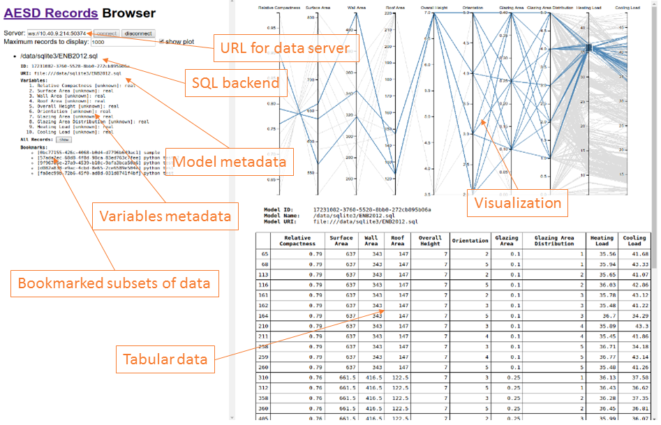

User interface for the Records API browser.

### 5.3.1 Connect to a server

**`connect(wsURL)`**

### 5.3.2 Disconnect from a server

**`disconnect(connection)`**

Here `connection` is the connection object returned by the `connect` function.

### 5.3.3 Retrieve list of data models

**`requestModelsMetadata(connection, modelId, notify, notifyError)`**

Here `connection` is the connection object returned by the `connect` function and `modelId` is either the string identifying the model or `null` if metadata for all models is requested. After all of the model metadata have been retrieved, the `notify` function is called with the list of model metadata objects as its argument; if an error occurs, `notifyError` is called with the error message as its argument. The function `requestModelsMetadata` returns a result object that contains a field `done` indicating whether all model metadata have been retrieved and a field `models` listing the model metadata retrieved so far.

### 5.3.4 Retrieve data records

**`requestRecordsData(connection, modelId, maxRecords, variableIds, bookmarkId, notify, notifyError)`**

Here `connection` is the connection object returned by the `connect` function and `modelId` is the string identifying the model. After all of the data records have been retrieved, the `notify` function is called with the list of data records as its argument; if an error occurs, `notifyError` is called with the error message as its argument. The `maxRecords` argument specifies the maximum number of records to retrieve, `variableIds` may list the variables of interest, and `bookmarkId` restricts the results to bookmarked records. The function `requestRecordsData` returns a result object that contains a field `done` indicating whether all data records have been retrieved and a field `data` listing the data records retrieved so far.

### 5.3.5 Retrieve list of bookmarks

**`requestBookmarkMeta(connection, modelId, bookmarkId, notify, notifyError)`**

Here `connection` is the connection object returned by the `connect` function, `modelId` is the string identifying the model, and `bookmarkId` is either the string identifying the bookmark or `null` if metadata for all bookmarks is requested. After all of the bookmark metadata have been retrieved, the `notify` function is called with the list of bookmark metadata as its argument; if an error occurs, `notifyError` is called with the error message as its argument. The function `requestBookmarkMeta` returns a result object that contains a field `done` indicating whether all bookmark metadata have been retrieved and a field `bookmarks` listing the bookmark metadata retrieved so far.

### 5.3.6 Create/update a bookmark

**`requestSaveBookmark(connection, modelId, name, filter, notify, notifyError)`**

Here `connection` is the connection object returned by the `connect` function, `modelId` is the string identifying the model, and `bookmarkId` is null for a new bookmark or the identifier for a bookmark being updated. The `name` field names the bookmark and the `filter` object describing the filtering operation for the bookmark. After the bookmark metadata has been created or updated, the `notify` function is called with the list of bookmark metadata as its argument; if an error occurs, then `notifyError` is called with the error message as its argument. The function `requestSaveBookmark` returns a result object that contains a field `done` indicating whether all bookmark metadata have been retrieved and a field `bookmarks` listing the bookmark metadata retrieved so far.

## 5.4 Python Client Library

Full documentation for the Python client library is available at <http://github.com/NREL/AESD/lib/python>.

### 5.4.1 Client API

**`new_server(self, server_url)`**

```
Change server url to which websocket will connnect
Parameters
----------
server_url : 'string'
    server url

Returns
---------
self.url : 'string'
    server url
```

**`send(self, request)`**

```
Closes event_loop
Parameters
----------
request : 'proto.request'
    proto request message
timeout : 'int'
    timeout in seconds for connection

Returns
---------
response : 'list'
    List of responses from the server, each response is a proto message
```

**`get_model_info(self, model_id)`**

```
Sends request of model metadata and extracts response
Parameters
----------
model_id : 'string'
    Id of model for which to requst models_metadata
    if None requests all models

Returns
-------
model_info : 'list'|'dict'
    List of model's metadata dictionaries for each model in models or
    dictionary for model_id
```

**`get_data(self, model_id, max_records=1000, variable_ids=None, bookmark_id=None)`**

```
Sends request of model metadata and extracts response
Parameters
----------
model_id : 'string'
    Id of model for which to requst records_data
max_records : 'int'
    Number or records being request (0 will return all records)
variable_ids : 'list'
    List of variable ids (ints) to be requested
    Will be returned in same order as request
    Default=None, all variables will be returned (order?)
bookmark_id : 'int'
    Request records_data based on bookmark id

Returns
-------
data : 'pd.DataFrame'
    Concatenated data from each response message
    Variable ids replaced with names from model_info
```

**`do_work(self, model_id, inputs)`**

```
Sends request of model metadata and extracts response
Parameters
----------
model_id : 'string'
    Id of model for which to requst records_data
inputs : 'dict'
    Dictionary of {var_id: value} pairs

Returns
-------
data : 'pd.DataFrame'
    Concatenated data from each response message
    Variable ids replaced with names from model_info
```

**`get_bookmark_info(self, model_id, bookmark_id)`**

```
Sends request of model metadata and extracts response
Parameters
----------
model_id : 'string'
    Id of model for which to requst bookmark_meta
bookmark_id : 'string'
    Id of bookmark for which to request models_metadata
    if None request all bookmarks

Returns
-------
model_info : 'list'|'dict'
    List of model's metadata dictionaries for each model in models or
    dictionary for model_id
```

**`save_bookmark(self, model_id, name, content)`**

```
Sends request to save new bookmark
Parameters
----------
model_id : 'string'
    Id of model for which to requst bookmark_meta
name : 'string'
    Name for new bookmark
content : 'list'|'tuple'
    Contents of bookmark
    list is a bookmark set
    tuple is a bookmark interval

Returns
-------
model_info : 'list'|'dict'
    List of model's metadata dictionaries for each model in models or
    dictionary for model_id
```

### 5.4.2 Example

The figure below shows example usage of the Python Records API client.

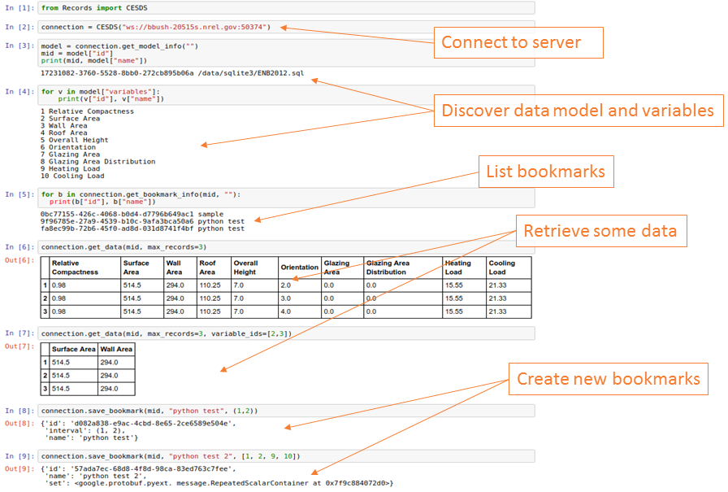

Example of a Python session using the Records API

# 6 Appendix

## 6.1 Protocol Buffers for Records API Version 4

```
syntax = "proto3";
package AesdRecords;

option optimize_for = LITE_RUNTIME;

message OptionalInt32 {
    int32 value = 1; /// [semantically required]
}

message OptionalUInt32 {
    uint32 value = 1; /// [semantically required]
}

message OptionalString {
    string value = 1; /// [semantically required]
}

message Value {
    oneof    value              /// [semantically required]
    {
      double real_value    = 1;
      int64  integer_value = 2;
      string string_value  = 3;
    }
}

message DoubleList {
    repeated double values = 1; /// [semantically required]
}

message IntegerList {
    repeated sint64 values = 1; /// [semantically required]
}

message StringList {
    repeated string values = 1; /// [semantically required]
}

message BookmarkIntervalContent {
    int64 first_record = 1; /// [semantically optional]
```

[output cut: 170 more lines]

```

message Request {
    uint32                  version         = 1; /// [semantically required]
    OptionalUInt32          id              = 2; /// [semantically optional, but recommended]
    bool                    subscribe       = 3; /// [semantically optional]
    oneof                   type                 /// [semantically required]
    {
        RequestModelsMeta   models_metadata = 4;
        RequestRecordsData  records_data    = 5;
        RequestBookmarkMeta bookmark_meta   = 6;
        RequestSaveBookmark save_bookmark   = 7;
        RequestCancel       cancel          = 8;
        RequestWork         work            = 9;
    }
}
```

# 7 Glossary of Acronyms

| Term | Definition |
| --- | --- |
| ACI | Application Container Image |
| AESD | Advanced Energy System Design |
| API | Application Programming Interface |
| C++ | a programming language |
| CSV | comma-separated-value file |
| Chrome | a web browser product |
| Firefox | a web browser product |
| Google Protocol Buffers | a serialization specification |
| HTTP | Hypertext Transfer Protocol |
| HTTPS | Hypertext Transfer Protocol Secure |
| Haskell | a programming language |
| IoT | the Internet of Thinks |
| JSON | JavaScript Object Notation |
| JavaScript | a programming language |
| MySQL | a database server product |
| NREL | National Renewable Energy Laboratory |
| ODBC | Open Database Connectivity |
| POSIX Epoch | seconds since midnight 1 January 1970 UTC |
| PostgreSQL | a database server product |
| Project Haystack | a specification for data feeds from the Internet of Thinks (IoT) |
| Python | a programming language |
| R | a programming language |
| REST | Representational State Transfer |
| rkt | a containger engine (CoreOS 2017b) |
| SQLite3 | a database server product |
| TSV | tab-separate-value file |
| URI | uniform resource identifier |
| UTC | Coordinate Universal Time |
| WebSockets | a communication protocol |
| YAML | YAML Ain’t Markup Language |

# 8 References

CoreOS. 2017a. “App Container Basics - Coreos.” Accessed September 6. https://coreos.com/rkt/docs/latest/app-container.html.

———. 2017b. “Rkt Container Engine with Coreos.” Accessed September 6. https://coreos.com/rkt.

Fowler, Martin. 2017. “UML Distilled.” Accessed April 11. http://my.safaribooksonline.com/book/software-engineering-and-development/uml/0321193687/sequence-diagrams/ch04.

Google Developers. 2017a. “Protocol Buffers - Google’s Data Interchange Format.” Accessed April 11. https://github.com/google/protobuf/blob/master/README.md.

———. 2017b. “Protocol Buffers | Google Developers.” Accessed April 11. https://developers.google.com/protocol-buffers/.

Internet Engineering Task Force. 2017. “RFC 6455 - the Websocket Protocol.” Accessed April 11. https://tools.ietf.org/html/rfc6455.

Oren Ben-Kiki, Clark Evans, Ingy döt Net. 2017. “YAML Specification Index.” Accessed September 6. http://www.yaml.org/spec/.

Project Haystack. 2017. “Home - Project Haystack.” Accessed September 6. http://project-haystack.org/.